# HW_0 Denis Grachev

Sorry, I missed some classes, so do not know the format of the homework.  
Hope this pdf of my jupyer notebook is fine.

$$ A = \begin{pmatrix} 4 & 0.5 & 1 \\ 2 & 0.5 & 1 \\ 4 & 1 & −0.9 \end{pmatrix} \\ b = \begin{pmatrix} 1 \\ 1 \\ 1 \end{pmatrix} $$

A. Gaussian elimination
$$ \left( \begin{array}{ccc|c} 4 & 0.5 & 1 & 1\\ 2 & 0.5 & 1 & 1\\ 4 & 1 & −0.9 & 1 \end{array} \right) $$ $$ \left( \begin{array}{ccc|c} 4 & 0.5 & 1 & 1\\ 0 & 0.25 & 0.5 & 0.5\\ 0 & 0.5 & −1.9 & 0 \end{array} \right) $$ $$ \left( \begin{array}{ccc|c} 4 & 0.5 & 1 & 1\\ 0 & 0.25 & 0.5 & 0.5\\ 0 & 0 & −2.9 & -1 \end{array} \right) $$ $$ \left( \begin{array}{ccc|c} 1 & 0.125 & 0.25 & 0.25 \\ 0 & 1 & 2 & 2\\ 0 & 0 & 1 & \frac{10}{29} \end{array} \right) $$

$$ \left( \begin{array}{ccc|c} 1 & 0.125 & 0 & \frac{1}{4} - \frac{10}{4*29} = \frac{19}{4*29} \\ 0 & 1 & 0 & \frac{38}{29}\\ 0 & 0 & 1 & \frac{10}{29} \end{array} \right) $$$$ \left( \begin{array}{ccc|c} 1 & 0 & 0 & 0 \\ 0 & 1 & 0 & \frac{38}{29}\\ 0 & 0 & 1 & \frac{10}{29} \end{array} \right) $$$$ x = \begin{pmatrix} 0 \\ \frac{38}{29} \\ \frac{10}{29} \end{pmatrix} $$

\begin{pmatrix} 1 & 0 & 0 \\ l_{2,1} & 1 & 0 \\ l_{3,1} & l_{3,2} & 1 \end{pmatrix}\begin{pmatrix} u_{1, 1} & u_{1, 2} & u_{1, 3} \\ 0 & u_{2, 2} & u_{2, 3} \\ 0 & 0 & u_{3, 3} \end{pmatrix}

- $1 \cdot u_{1, 1} = 4 \Rightarrow u_{1, 1} = 4$
- $1 \cdot u_{1, 2} = 0.5 \Rightarrow u_{1, 2} = 0.5$
- $1 \cdot u_{1, 3} = 1 \Rightarrow u_{1, 3} = 1$
- $u_{1, 1} l_{2, 1} = 2 \Rightarrow l_{2, 1} = 2 : 4 = 0.5$
- $l_{2, 1} u_{1, 2} + 1 \cdot u_{2, 2} = 0.5 \Rightarrow 0.25 + u_{2, 2} = 0.5 \Rightarrow u_{2, 2} = 0.25$
- $l_{2, 1} u_{1, 3} + 1 \cdot u_{2, 3} = 1 \Rightarrow 0.5 + u_{2, 3} = 1 \Rightarrow u_{2, 3} = 0.5$
- $l_{3, 1} u_{1, 1} = 4 \Rightarrow l_{3, 1} = 1$
- $l_{3, 1} u_{1, 2} + l_{3, 2} u_{2, 2} = 1 \Rightarrow 0.5 + 0.25 l_{3,2} = 1 \Rightarrow l_{3, 2} = 2$
- $l_{3, 1} u_{1, 3} + l_{3, 2} u_{2, 3} + 1 \cdot u_{3, 3} = 0.9 \Rightarrow 1 + 1 + u_{3, 3} = 0.9 \Rightarrow u_{3, 3} = -1.1$

$$ A = \begin{pmatrix} 4 & 0.5 & 1 \\ 2 & 0.5 & 1 \\ 4 & 1 & 0.9 \end{pmatrix} = \begin{pmatrix} 1 & 0 & 0 \\ 0.5 & 1 & 0 \\ 1 & 2 & 1 \end{pmatrix} \begin{pmatrix} 4 & 0.5 & 1 \\ 0 & 0.25 & 0.5 \\ 0 & 0 & -1.1 \end{pmatrix} $$

$$ \begin{pmatrix} 1 & 0 & 0 \\ 0.5 & 1 & 0 \\ 1 & 2 & 1 \end{pmatrix} \begin{pmatrix} 4 & 0.5 & 1 \\ 0 & 0.25 & 0.5 \\ 0 & 0 & -1.1 \end{pmatrix} x = \begin{pmatrix} 1 \\ 1 \\ 1 \end{pmatrix} $$$$ \begin{pmatrix} 4 & 0.5 & 1 \\ 0 & 0.25 & 0.5 \\ 0 & 0 & -1.1 \end{pmatrix} x = \begin{pmatrix} 1 & 0 & 0 \\ 0.5 & 1 & 0 \\ 1 & 2 & 1 \end{pmatrix}^{-1} \begin{pmatrix} 1 \\ 1 \\ 1 \end{pmatrix} $$$$ \begin{pmatrix} 4 & 0.5 & 1 \\ 0 & 0.25 & 0.5 \\ 0 & 0 & -1.1 \end{pmatrix} x = \begin{pmatrix} 1 & 0 & 0 \\ -0.5 & -1 & 0 \\ 0 & 2 & -1 \end{pmatrix} \begin{pmatrix} 1 \\ 1 \\ 1 \end{pmatrix} $$$$ \begin{pmatrix} 4 & 0.5 & 1 \\ 0 & 0.25 & 0.5 \\ 0 & 0 & -1.1 \end{pmatrix} x = \begin{pmatrix} 1 \\ -1.5\\ 1 \end{pmatrix} $$$$ x = \begin{pmatrix} 4 & 0.5 & 1 \\ 0 & 0.25 & 0.5 \\ 0 & 0 & -1.1 \end{pmatrix} ^ {-1} \begin{pmatrix} 1 \\ -1.5\\ 1 \end{pmatrix} $$$$ x = \begin{pmatrix} \frac{1}{4} & -\frac{1}{2} & 0 \\ 0 & 4 & \frac{20}{11} \\ 0 & 0 & -\frac{10}{11} \end{pmatrix} \begin{pmatrix} 1 \\ -\frac{3}{2}\\ 1 \end{pmatrix} $$$$ x = \begin{pmatrix} 1 \\ -\frac{46}{11}\\ -\frac{10}{11} \end{pmatrix} $$

Obviously there is an error in my calculations, becouse the answers do not match. But I can not find one.

C. Cholesky decomposition $$ A = \begin{pmatrix} 4 & 0.5 & 1 \\ 2 & 0.5 & 1 \\ 4 & 1 & 0.9 \end{pmatrix} = L L^T $$

$$ L = \begin{pmatrix} \sqrt{A_{1, 1}} & 0 & 0 \\ \frac{A_{2, 1}}{L_{1, 1}} & \sqrt{A_{2, 2} - L_{2, 1}^2} & 0 \\ \frac{A_{3, 1}}{L_{1, 1}} & \frac{A_{3, 2} - L_{3, 1} L_{2, 1}}{L_{2, 2}} & \sqrt{A_{3, 3} - L_{3, 1}^2 - L_{3, 2}^2} \end{pmatrix} $$

$$ L = \begin{pmatrix} 2 & 0 & 0 \\ 1 & \sqrt{0.5 - 1^2} & 0 \\ & \ldots & \end{pmatrix} $$

Can not be resolved over real numbers

D. Computational methods

```python
import numpy as np
import matplotlib.pyplot as plt
from scipy.linalg.lapack import dtrtri
```

```python
A = np.array([
    [4, 0.5, 1],
    [2, 0.5, 1],
    [4, 1, -0.9],
])

b = np.array([1, 1, 1], dtype=np.float64)
```

```python
L = np.tril(A)
L_inv = dtrtri(L, lower=0)[0]
L @ L_inv
```

```
array([[ 1. ,  0. ,  0. ],
       [ 1.5,  1. ,  0. ],
       [-0.6,  1.1,  1. ]])
```

Why `dtrtri` does not work?  
I will use `np.linalg.inv` for now, becouse matrix is small and it does not matter a lot.  
But for bigger systems special methods for inversion triangular matricies supposed to be used.

```python
def richardson_iter(A, b, x_0, dump=1, max_iter=100, eps=1e-6, save_hist=True):
    x = x_0.copy()

    if save_hist:
        hist_residual = []

    for _ in range(max_iter):
        res = b - A @ x
        res_norm = np.linalg.norm(res)

        if res_norm < eps:
            break

        if save_hist:
            hist_residual.append(res_norm)

        x += dump * res

    if save_hist:
        return x, hist_residual

    return x
```

```python
def jacobi_iter(A, b, x_0, max_iter=100, eps=1e-6, save_hist=True):
    x = x_0.copy()

    if save_hist:
        hist_residual = []

    D = np.diag(A) # Note D is vector, not matrix
    L_U = A - D

    for _ in range(max_iter):
        res = b - A @ x
        res_norm = np.linalg.norm(res)

        if res_norm < eps:
            break

        if save_hist:
            hist_residual.append(res_norm)

        x = (1 / D) * (b - (L_U @ x))

    if save_hist:
        return x, hist_residual

    return x
```

```python
def gauss_siden_iter(A, b, x_0, max_iter=100, eps=1e-6, save_hist=True):
    x = x_0.copy()

    if save_hist:
        hist_residual = []

    L = np.tril(A, 0)
    U = np.triu(A, 1)
    L_inv = np.linalg.inv(L)

    for _ in range(max_iter):
        res = b - A @ x
        res_norm = np.linalg.norm(res)

        if res_norm < eps:
            break

        if save_hist:
            hist_residual.append(res_norm)

        x = L_inv @ (b - U @ x)

    if save_hist:
        return x, hist_residual

    return x
```

## Initial A

```python
iters = 100
_, hist_rich_1 = richardson_iter(A, b, b, 1, iters)
_, hist_rich_01 = richardson_iter(A, b, b, 0.1, iters)
_, hist_rich_001 = richardson_iter(A, b, b, 0.01, iters)
_, hist_jacobi = jacobi_iter(A, b, b, iters)
_, hist_gauss = gauss_siden_iter(A, b, b, iters)
x = np.arange(iters) + 1
```

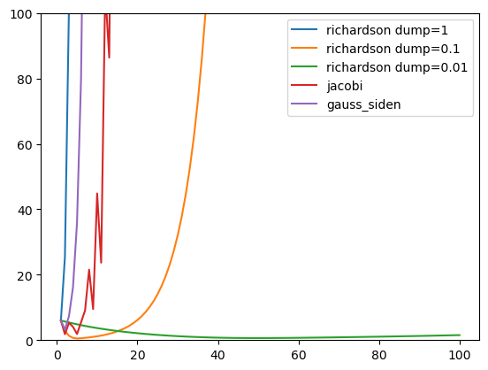

```python
plt.plot(x, hist_rich_1, label='richardson dump=1')
plt.plot(x, hist_rich_01, label='richardson dump=0.1')
plt.plot(x, hist_rich_001, label='richardson dump=0.01')
plt.plot(x, hist_jacobi, label='jacobi')
plt.plot(x, hist_gauss, label='gauss_siden')

ax = plt.gca()
ax.set_ylim([0, 100])
plt.legend()
plt.show()
```

- Richardson with small dumping seems to almost converge, but it will diverge with more iterations
- All the other methods diverge very quickly

Let's test same methods but on SP matrix

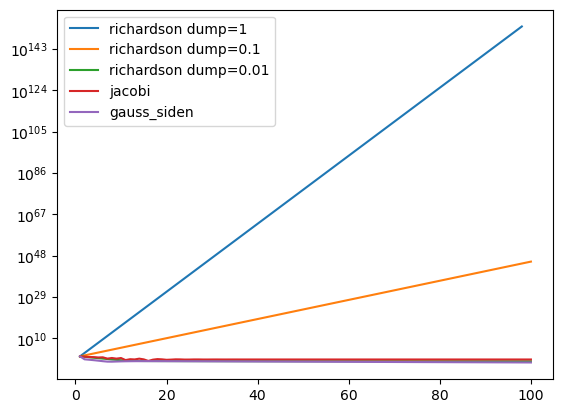

```python
iters = 100
_, hist_rich_1 = richardson_iter(A @ A.T, b, b, 1, iters)
_, hist_rich_01 = richardson_iter(A @ A.T, b, b, 0.1, iters)
_, hist_rich_001 = richardson_iter(A @ A.T, b, b, 0.01, iters)
_, hist_jacobi = jacobi_iter(A @ A.T, b, b, iters)
_, hist_gauss = gauss_siden_iter(A @ A.T, b, b, iters)
x = np.arange(iters) + 1
plt.plot(x, hist_rich_1, label='richardson dump=1')
plt.plot(x, hist_rich_01, label='richardson dump=0.1')
plt.plot(x, hist_rich_001, label='richardson dump=0.01')
plt.plot(x, hist_jacobi, label='jacobi')
plt.plot(x, hist_gauss, label='gauss_siden')

ax = plt.gca()
plt.yscale('log')
plt.legend()
plt.show()
```

Remove dumping 1 and 0.1

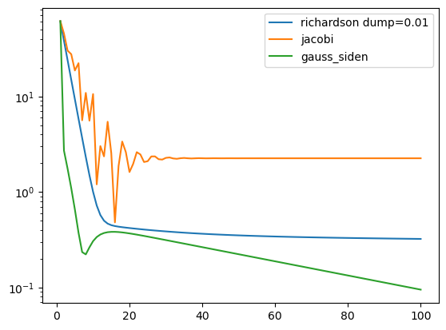

```python
iters = 100
_, hist_rich_001 = richardson_iter(A @ A.T, b, b, 0.01, iters)
_, hist_jacobi = jacobi_iter(A @ A.T, b, b, iters)
_, hist_gauss = gauss_siden_iter(A @ A.T, b, b, iters)
x = np.arange(iters) + 1
plt.plot(x, hist_rich_001, label='richardson dump=0.01')
plt.plot(x, hist_jacobi, label='jacobi')
plt.plot(x, hist_gauss, label='gauss_siden')

ax = plt.gca()
plt.yscale('log')
plt.legend()
plt.show()
```

Gauss Siden methods converges quicker than others.